# 第15节：生物数据建模综合实验（预处理-相关性-回归-分类-检验）

HuangJIn

2026-04-18

# 1 学习目标

- 使用真实生物医学数据完成一次端到端统计建模实验
- 掌握数据预处理、相关性分析、回归与分类的统一流程
- 比较线性回归、多项式回归、全连接神经网络在回归任务上的差异
- 通过假设检验与区间估计形成可解释的统计结论

# 2 1. 数据集与任务定义

本节使用 `survival` 包中的 `lung` 数据集（晚期肺癌临床数据）。  
我们定义两个核心任务：

1. 回归任务：预测生存时间 `time`（连续变量）
2. 分类任务：预测是否发生死亡事件 `dead`（0/1）

## 2.1 1.1 研究背景与数据结构（详细）

- 研究背景：`lung` 数据来自晚期肺癌患者临床随访，包含人口学信息、功能状态评分、体重变化与生存结局。
- 样本单位：单个患者。
- 响应变量（回归）：`time`，单位为天。
- 响应变量（分类）：`dead`，由 `status` 映射得到（死亡=1，其他=0）。
- 主要解释变量：`age`、`sex`、`ph.ecog`（ECOG 体能状态）、`ph.karno`（Karnofsky 评分）、`wt.loss`（体重变化）。
- 研究目标：在同一数据集上比较“解释性模型”和“灵活预测模型”的表现差异，并形成可解释的统计结论。

## 2.2 1.2 本节任务清单（可报告版本）

1. 数据预处理：缺失处理、变量编码、训练/测试划分、标准化。
2. 相关性分析：连续变量之间相关方向与显著性。
3. 回归建模：线性回归、多项式回归、全连接神经网络，对 `time` 做预测并比较误差。
4. 分类建模：逻辑回归、全连接神经网络，对 `dead` 做概率预测并比较分类指标。
5. 统计推断：完成组间假设检验并报告区间估计。
6. 结论整合：给出“何时优先解释、何时优先预测”的方法建议。

```r
set.seed(20260412)
library(survival)
library(RSNNS)
```

```r
library(ggplot2)

academic_theme <- theme_bw(base_size = 12) +
  theme(
    plot.title = element_text(face = "bold", hjust = 0.5),
    plot.subtitle = element_text(hjust = 0.5),
    axis.title = element_text(face = "bold"),
    legend.title = element_text(face = "bold"),
    legend.position = "right",
    panel.grid.minor = element_blank(),
    panel.border = element_rect(color = "black", linewidth = 0.7)
  )
theme_set(academic_theme)

raw <- survival::lung[, c("time", "status", "age", "sex", "ph.ecog", "ph.karno", "wt.loss")]
raw$dead <- ifelse(raw$status == 2, 1, 0)
raw$sex <- factor(raw$sex, levels = c(1, 2), labels = c("male", "female"))

str(raw)
```

```
## 'data.frame':    228 obs. of  8 variables:
##  $ time    : num  306 455 1010 210 883 ...
##  $ status  : num  2 2 1 2 2 1 2 2 2 2 ...
##  $ age     : num  74 68 56 57 60 74 68 71 53 61 ...
##  $ sex     : Factor w/ 2 levels "male","female": 1 1 1 1 1 1 2 2 1 1 ...
##  $ ph.ecog : num  1 0 0 1 0 1 2 2 1 2 ...
##  $ ph.karno: num  90 90 90 90 100 50 70 60 70 70 ...
##  $ wt.loss : num  NA 15 15 11 0 0 10 1 16 34 ...
##  $ dead    : num  1 1 0 1 1 0 1 1 1 1 ...
```

```r
summary(raw)
```

```
##       time            status           age            sex         ph.ecog
##  Min.   :   5.0   Min.   :1.000   Min.   :39.00   male  :138   Min.   :0.0000
##  1st Qu.: 166.8   1st Qu.:1.000   1st Qu.:56.00   female: 90   1st Qu.:0.0000
##  Median : 255.5   Median :2.000   Median :63.00                Median :1.0000
##  Mean   : 305.2   Mean   :1.724   Mean   :62.45                Mean   :0.9515
##  3rd Qu.: 396.5   3rd Qu.:2.000   3rd Qu.:69.00                3rd Qu.:1.0000
##  Max.   :1022.0   Max.   :2.000   Max.   :82.00                Max.   :3.0000
##                                                                NA's   :1
##     ph.karno         wt.loss             dead
##  Min.   : 50.00   Min.   :-24.000   Min.   :0.0000
##  1st Qu.: 75.00   1st Qu.:  0.000   1st Qu.:0.0000
##  Median : 80.00   Median :  7.000   Median :1.0000
##  Mean   : 81.94   Mean   :  9.832   Mean   :0.7237
##  3rd Qu.: 90.00   3rd Qu.: 15.750   3rd Qu.:1.0000
##  Max.   :100.00   Max.   : 68.000   Max.   :1.0000
##  NA's   :1        NA's   :14
```

## 2.3 1.3 数据概览可视化

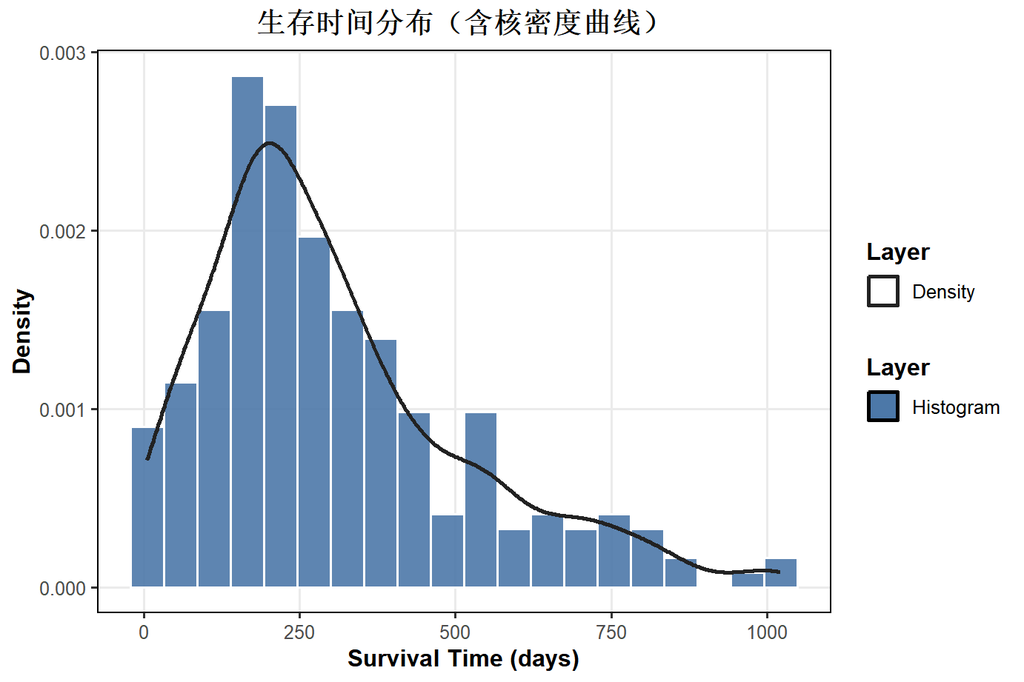

```r
plot_df <- raw[!is.na(raw$time) & !is.na(raw$sex), ]

ggplot(plot_df, aes(x = time)) +
  geom_histogram(aes(y = after_stat(density), fill = "Histogram"), bins = 20, color = "white", alpha = 0.9) +
  geom_density(aes(color = "Density"), linewidth = 1.0) +
  scale_fill_manual(values = c(Histogram = "#4C78A8"), name = "Layer") +
  scale_color_manual(values = c(Density = "#222222"), name = "Layer") +
  labs(
    title = "生存时间分布（含核密度曲线）",
    x = "Survival Time (days)",
    y = "Density"
  )
```

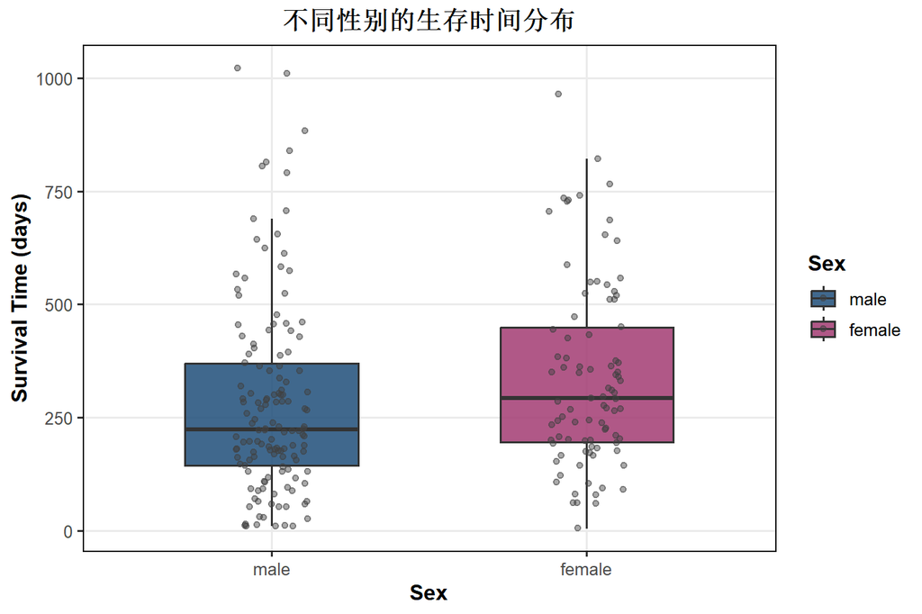

```r
ggplot(plot_df, aes(x = sex, y = time, fill = sex)) +
  geom_boxplot(width = 0.55, alpha = 0.85, outlier.shape = NA) +
  geom_jitter(width = 0.12, alpha = 0.45, size = 1.4, color = "gray25") +
  scale_fill_manual(values = c(male = "#1F4E79", female = "#A23B72")) +
  labs(
    title = "不同性别的生存时间分布",
    x = "Sex",
    y = "Survival Time (days)",
    fill = "Sex"
  )
```

# 3 2. 数据预处理

问题描述：原始临床数据常见缺失与异构编码问题，若不统一处理会造成模型偏差或训练失败。本节目标是构建可复现、可直接用于建模的数据版本。

## 3.1 2.1 缺失值与变量处理

设原始特征向量为 $x=(x_1,\dots,x_p)$，中位数填补可写为：
$$\tilde x_j=
\begin{cases}
\text{median}(x_j), & x_j\text{ 缺失}\\
x_j, & \text{否则}
\end{cases}$$

标准化（用于神经网络）定义为：
$$z_j = \frac{x_j-\mu_j}{s_j},$$
其中 $\mu_j$ 与 $s_j$ 仅在训练集上估计。

```r
df <- raw

# 删除关键变量缺失
n_before <- nrow(df)
df <- df[!is.na(df$time) & !is.na(df$dead), ]

# 中位数填补
num_impute <- c("age", "ph.ecog", "ph.karno", "wt.loss")
for (col in num_impute) {
  med <- median(df[[col]], na.rm = TRUE)
  df[[col]][is.na(df[[col]])] <- med
}

n_after <- nrow(df)
missing_after <- colSums(is.na(df))

list(n_before = n_before, n_after = n_after, missing_after = missing_after)
```

```
## $n_before
## [1] 228
##
## $n_after
## [1] 228
##
## $missing_after
##     time   status      age      sex  ph.ecog ph.karno  wt.loss     dead
##        0        0        0        0        0        0        0        0
```

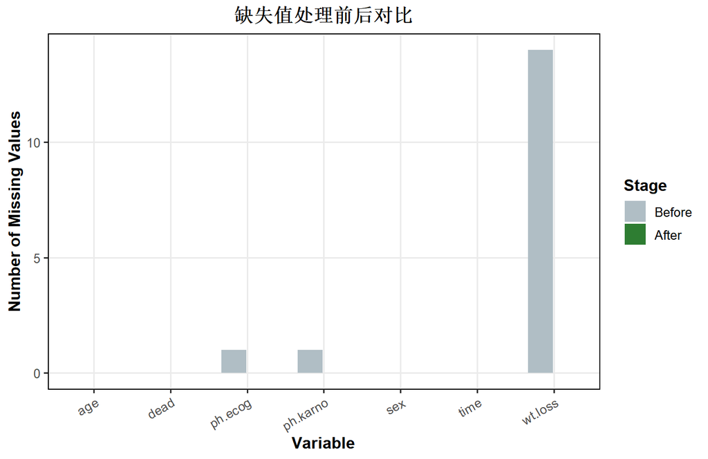

```r
vars_show <- c("time", "dead", "age", "sex", "ph.ecog", "ph.karno", "wt.loss")
miss_before <- colSums(is.na(raw[, vars_show]))
miss_after <- colSums(is.na(df[, vars_show]))

miss_plot <- rbind(
  data.frame(variable = names(miss_before), stage = "Before", missing_n = as.numeric(miss_before)),
  data.frame(variable = names(miss_after), stage = "After", missing_n = as.numeric(miss_after))
)
miss_plot$stage <- factor(miss_plot$stage, levels = c("Before", "After"))

ggplot(miss_plot, aes(x = variable, y = missing_n, fill = stage)) +
  geom_col(position = position_dodge(width = 0.7), width = 0.65) +
  scale_fill_manual(values = c(Before = "#B0BEC5", After = "#2E7D32")) +
  labs(
    title = "缺失值处理前后对比",
    x = "Variable",
    y = "Number of Missing Values",
    fill = "Stage"
  ) +
  theme(axis.text.x = element_text(angle = 30, hjust = 1))
```

## 3.2 2.2 训练集/测试集划分

```r
set.seed(20260412)
idx <- sample(seq_len(nrow(df)), size = round(0.7 * nrow(df)))
train <- df[idx, ]
test <- df[-idx, ]

c(train_n = nrow(train), test_n = nrow(test))
```

```
## train_n  test_n
##     160      68
```

# 4 3. 相关性分析

问题描述：在进入多模型实验前，先回答“哪些变量与生存时间线性相关、方向如何、显著性如何”，用于辅助特征理解与模型解释。

Pearson 相关系数定义为：
$$r_{XY}=\frac{\sum_{i=1}^n (x_i-\bar x)(y_i-\bar y)}
{\sqrt{\sum_{i=1}^n (x_i-\bar x)^2}\sqrt{\sum_{i=1}^n (y_i-\bar y)^2}}.$$

```r
num_vars <- df[, c("time", "age", "ph.ecog", "ph.karno", "wt.loss", "dead")]
cor_mat <- round(cor(num_vars, method = "pearson"), 3)
cor_mat
```

```
##            time    age ph.ecog ph.karno wt.loss   dead
## time      1.000 -0.078  -0.201    0.133   0.017 -0.171
## age      -0.078  1.000   0.193   -0.203   0.038  0.150
## ph.ecog  -0.201  0.193   1.000   -0.799   0.176  0.233
## ph.karno  0.133 -0.203  -0.799    1.000  -0.168 -0.183
## wt.loss   0.017  0.038   0.176   -0.168   1.000  0.028
## dead     -0.171  0.150   0.233   -0.183   0.028  1.000
```

```r
cor_age <- cor.test(df$time, df$age)
cor_ecog <- cor.test(df$time, df$ph.ecog)
cor_karno <- cor.test(df$time, df$ph.karno)
cor_wt <- cor.test(df$time, df$wt.loss)

data.frame(
  feature = c("age", "ph.ecog", "ph.karno", "wt.loss"),
  r = round(c(cor_age$estimate, cor_ecog$estimate, cor_karno$estimate, cor_wt$estimate), 3),
  p_value = signif(c(cor_age$p.value, cor_ecog$p.value, cor_karno$p.value, cor_wt$p.value), 4)
)
```

```
##    feature      r  p_value
## 1      age -0.078 0.240500
## 2  ph.ecog -0.201 0.002341
## 3 ph.karno  0.133 0.044090
## 4  wt.loss  0.017 0.792800
```

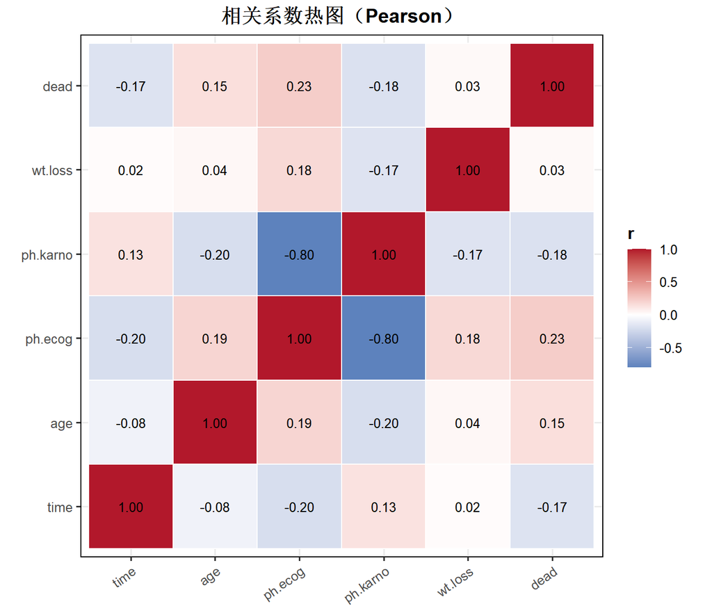

```r
cor_df <- as.data.frame(as.table(cor_mat))
colnames(cor_df) <- c("Var1", "Var2", "corr")

ggplot(cor_df, aes(x = Var1, y = Var2, fill = corr)) +
  geom_tile(color = "white", linewidth = 0.4) +
  geom_text(aes(label = sprintf("%.2f", corr)), size = 3.4) +
  scale_fill_gradient2(low = "#2166AC", mid = "white", high = "#B2182B", midpoint = 0) +
  labs(
    title = "相关系数热图（Pearson）",
    x = NULL,
    y = NULL,
    fill = "r"
  ) +
  coord_equal() +
  theme(axis.text.x = element_text(angle = 35, hjust = 1))
```

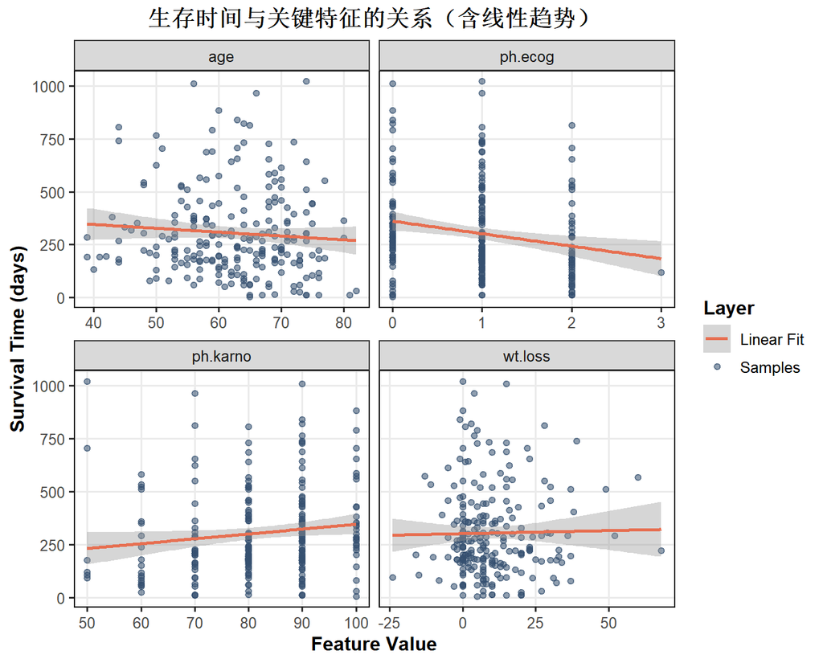

```r
scatter_df <- rbind(
  data.frame(feature = "age", x = df$age, time = df$time),
  data.frame(feature = "ph.ecog", x = df$ph.ecog, time = df$time),
  data.frame(feature = "ph.karno", x = df$ph.karno, time = df$time),
  data.frame(feature = "wt.loss", x = df$wt.loss, time = df$time)
)

ggplot(scatter_df, aes(x = x, y = time)) +
  geom_point(aes(color = "Samples"), alpha = 0.55, size = 1.5) +
  geom_smooth(aes(color = "Linear Fit"), method = "lm", se = TRUE, linewidth = 0.9) +
  scale_color_manual(values = c("Samples" = "#355070", "Linear Fit" = "#E76F51"), name = "Layer") +
  facet_wrap(~ feature, scales = "free_x", ncol = 2) +
  labs(
    title = "生存时间与关键特征的关系（含线性趋势）",
    x = "Feature Value",
    y = "Survival Time (days)"
  )
```

# 5 4. 回归实验（线性 / 多项式 / 全连接神经网络）

问题描述（回归任务）：

- 研究问题：能否根据基线临床特征预测患者生存时间 `time`？
- 评价重点：预测误差（RMSE/MAE）与拟合解释程度（R2）。
- 比较目标：
  1. 线性回归：高可解释性基线；
  2. 多项式回归：引入有限非线性；
  3. 全连接神经网络：高表达能力但可解释性较弱。
- 判定原则：以测试集 RMSE 为主指标，MAE/R2 为辅助。

## 5.1 4.1 模型公式推导

线性回归模型：
$$y_i=\beta_0+\sum_{j=1}^p\beta_j x_{ij}+\varepsilon_i,
\quad \hat\beta=\arg\min_\beta \sum_{i=1}^n (y_i-\hat y_i)^2.$$

多项式回归（以二次项为例）：
$$y_i=\beta_0+\beta_1x_i+\beta_2x_i^2+\cdots+\varepsilon_i.$$

全连接神经网络（3 个隐藏层、每层 4 个节点）可写为：
$$\hat y =
W_4\,\sigma\!\big(W_3\,\sigma(W_2\,\sigma(W_1x+b_1)+b_2)+b_3\big)+b_4,$$
其中 $\sigma(\cdot)$ 为激活函数，参数通过最小化损失函数（如 MSE）迭代学习。

## 5.2 4.2 回归建模与评估

```r
# 线性回归
lm_fit <- lm(time ~ age + sex + ph.ecog + ph.karno + wt.loss, data = train)
pred_lm_train <- predict(lm_fit, newdata = train)
pred_lm <- predict(lm_fit, newdata = test)

# 多项式回归
poly_fit <- lm(
  time ~ poly(age, 2, raw = TRUE) + poly(wt.loss, 2, raw = TRUE) + sex + ph.ecog + ph.karno,
  data = train
)
pred_poly_train <- predict(poly_fit, newdata = train)
pred_poly <- predict(poly_fit, newdata = test)

# 全连接神经网络回归（3 隐藏层 x 每层 4 节点）
x_train <- model.matrix(~ age + sex + ph.ecog + ph.karno + wt.loss, data = train)[, -1]
x_test <- model.matrix(~ age + sex + ph.ecog + ph.karno + wt.loss, data = test)[, -1]

x_train_sc <- scale(x_train)
x_test_sc <- scale(x_test, center = attr(x_train_sc, "scaled:center"), scale = attr(x_train_sc, "scaled:scale"))

y_train <- train$time
y_mean <- mean(y_train)
y_sd <- sd(y_train)
y_train_sc <- (y_train - y_mean) / y_sd

set.seed(20260412)
nn_reg <- mlp(
  x_train_sc,
  matrix(y_train_sc, ncol = 1),
  size = c(4, 4, 4),
  maxit = 500,
  learnFuncParams = c(0.05),
  linOut = TRUE
)

pred_nn_train_sc <- as.numeric(predict(nn_reg, x_train_sc))
pred_nn_sc <- as.numeric(predict(nn_reg, x_test_sc))
pred_nn_train <- pred_nn_train_sc * y_sd + y_mean
pred_nn <- pred_nn_sc * y_sd + y_mean

metric_reg <- function(y_true, y_pred) {
  mse <- mean((y_true - y_pred)^2)
  rmse <- sqrt(mean((y_true - y_pred)^2))
  mae <- mean(abs(y_true - y_pred))
  r2 <- 1 - sum((y_true - y_pred)^2) / sum((y_true - mean(y_true))^2)
  c(MSE = mse, RMSE = rmse, MAE = mae, R2 = r2)
}

reg_cmp_train <- rbind(
  linear = metric_reg(train$time, pred_lm_train),
  polynomial = metric_reg(train$time, pred_poly_train),
  neural_net = metric_reg(train$time, pred_nn_train)
)

reg_cmp_test <- rbind(
  linear = metric_reg(test$time, pred_lm),
  polynomial = metric_reg(test$time, pred_poly),
  neural_net = metric_reg(test$time, pred_nn)
)
reg_cmp <- reg_cmp_test
round(reg_cmp_test, 4)
```

```
##                 MSE     RMSE      MAE      R2
## linear     31919.39 178.6600 144.4135 -0.0082
## polynomial 38188.05 195.4176 156.3399 -0.2062
## neural_net 35655.23 188.8259 157.4136 -0.1262
```

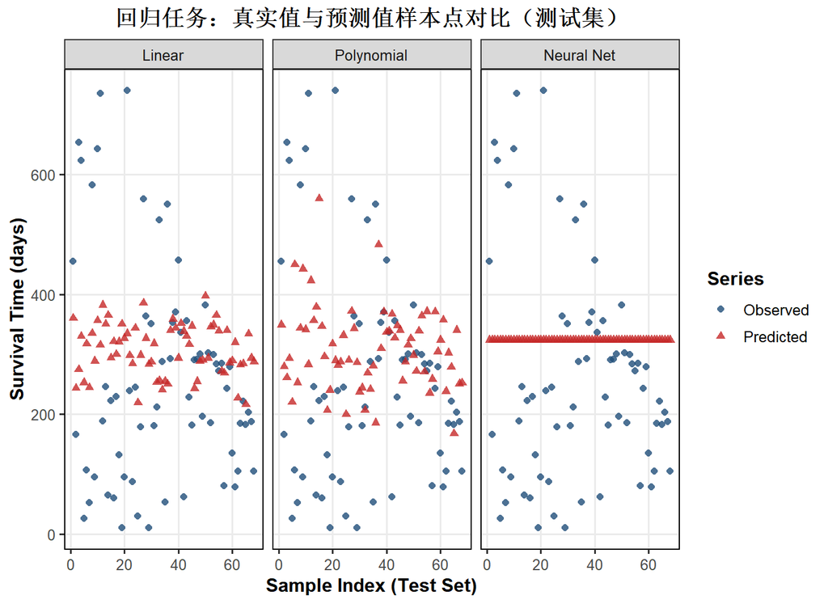

```r
sample_id <- seq_len(nrow(test))
pred_plot <- rbind(
  data.frame(model = "Linear", sample_id = sample_id, series = "Observed", value = test$time),
  data.frame(model = "Linear", sample_id = sample_id, series = "Predicted", value = pred_lm),
  data.frame(model = "Polynomial", sample_id = sample_id, series = "Observed", value = test$time),
  data.frame(model = "Polynomial", sample_id = sample_id, series = "Predicted", value = pred_poly),
  data.frame(model = "Neural Net", sample_id = sample_id, series = "Observed", value = test$time),
  data.frame(model = "Neural Net", sample_id = sample_id, series = "Predicted", value = pred_nn)
)
pred_plot$model <- factor(pred_plot$model, levels = c("Linear", "Polynomial", "Neural Net"))
pred_plot$series <- factor(pred_plot$series, levels = c("Observed", "Predicted"))

ggplot(pred_plot, aes(x = sample_id, y = value, color = series, shape = series)) +
  geom_point(alpha = 0.8, size = 1.8) +
  facet_wrap(~ model, ncol = 3) +
  scale_color_manual(values = c("Observed" = "#1F4E79", "Predicted" = "#C62828")) +
  labs(
    title = "回归任务：真实值与预测值样本点对比（测试集）",
    x = "Sample Index (Test Set)",
    y = "Survival Time (days)",
    color = "Series",
    shape = "Series"
  )
```

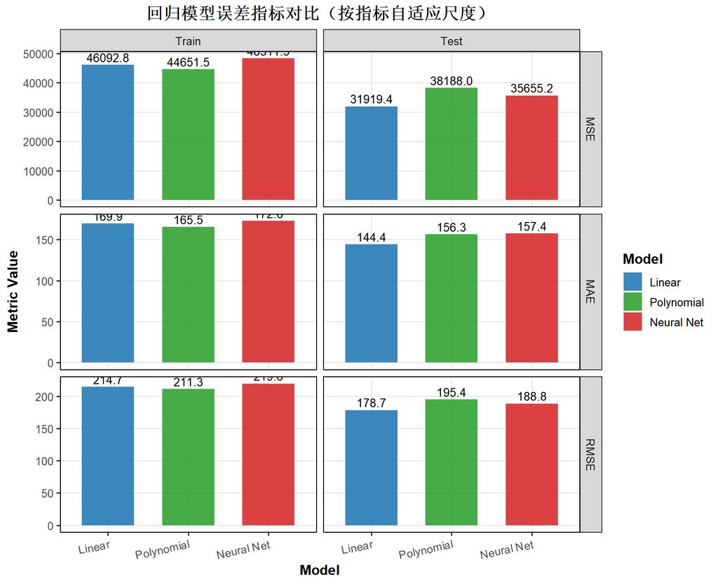

```r
to_long_metric <- function(mat, split_name) {
  reg_metric_df <- data.frame(
    model = rownames(mat),
    split = split_name,
    MSE = mat[, "MSE"],
    MAE = mat[, "MAE"],
    RMSE = mat[, "RMSE"],
    row.names = NULL
  )
  rbind(
    data.frame(model = reg_metric_df$model, split = reg_metric_df$split, metric = "MSE", value = reg_metric_df$MSE),
    data.frame(model = reg_metric_df$model, split = reg_metric_df$split, metric = "MAE", value = reg_metric_df$MAE),
    data.frame(model = reg_metric_df$model, split = reg_metric_df$split, metric = "RMSE", value = reg_metric_df$RMSE)
  )
}

reg_metric_long <- rbind(
  to_long_metric(reg_cmp_train, "Train"),
  to_long_metric(reg_cmp_test, "Test")
)
reg_metric_long$model <- factor(reg_metric_long$model, levels = c("linear", "polynomial", "neural_net"),
                                labels = c("Linear", "Polynomial", "Neural Net"))
reg_metric_long$metric <- factor(reg_metric_long$metric, levels = c("MSE", "MAE", "RMSE"))
reg_metric_long$split <- factor(reg_metric_long$split, levels = c("Train", "Test"))

ggplot(reg_metric_long, aes(x = model, y = value, fill = model)) +
  geom_col(width = 0.65, alpha = 0.88) +
  geom_text(aes(label = sprintf("%.1f", value)), vjust = -0.35, size = 3.5) +
  facet_grid(metric ~ split, scales = "free_y") +
  scale_fill_manual(values = c("Linear" = "#1F77B4", "Polynomial" = "#2CA02C", "Neural Net" = "#D62728")) +
  labs(
    title = "回归模型误差指标对比（按指标自适应尺度）",
    x = "Model",
    y = "Metric Value",
    fill = "Model"
  ) +
  theme(axis.text.x = element_text(angle = 12, hjust = 1))
```

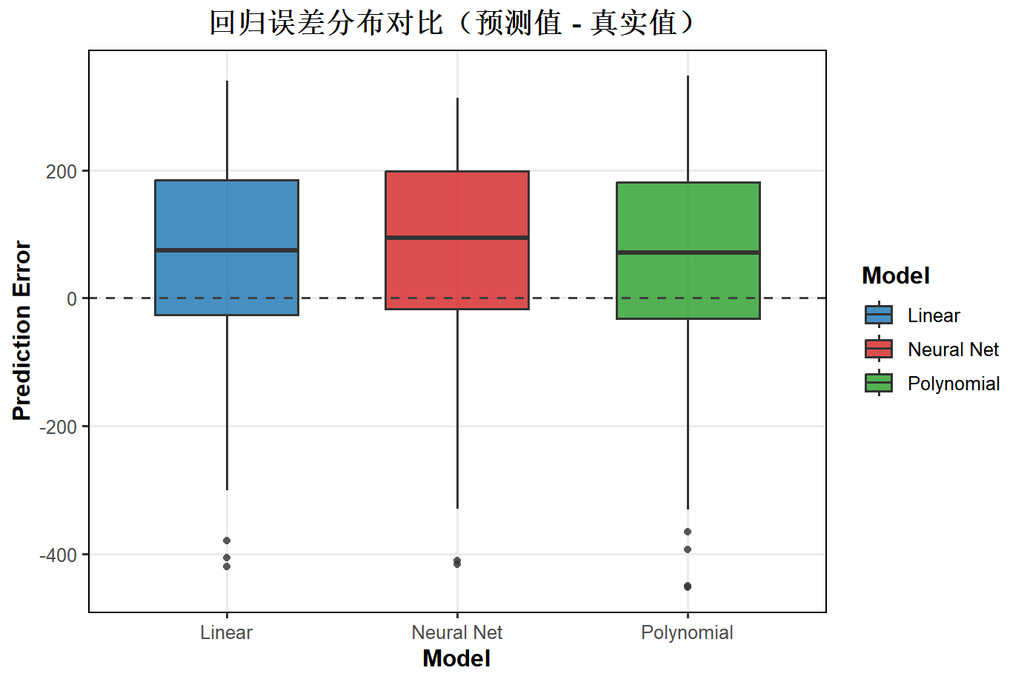

```r
err_plot <- rbind(
  data.frame(model = "Linear", error = pred_lm - test$time),
  data.frame(model = "Polynomial", error = pred_poly - test$time),
  data.frame(model = "Neural Net", error = pred_nn - test$time)
)

ggplot(err_plot, aes(x = model, y = error, fill = model)) +
  geom_boxplot(alpha = 0.82, width = 0.62, outlier.shape = 16, outlier.size = 1.4) +
  geom_hline(yintercept = 0, linetype = "dashed", color = "gray25") +
  scale_fill_manual(values = c("Linear" = "#1F77B4", "Polynomial" = "#2CA02C", "Neural Net" = "#D62728")) +
  labs(
    title = "回归误差分布对比（预测值 - 真实值）",
    x = "Model",
    y = "Prediction Error",
    fill = "Model"
  )
```

## 5.3 4.3 回归结果分析

为什么本实验中神经网络提升不明显，甚至略差：

1. 样本量相对较小。训练集约为 160 例，而 3 层网络参数较多，容易在有限样本上训练不稳定。
2. 特征数量少且关系偏“弱非线性”。本数据里变量不多（5 个主要输入），线性/低阶非线性模型已经能覆盖主要信号。
3. 结局变量存在较大噪声与异质性。`time` 受治疗方案、未观测临床因素影响明显，模型上限受数据噪声限制。
4. 当前是“单次划分 + 默认超参数”实验。神经网络通常需要更系统的超参数搜索（学习率、迭代轮数、正则化、早停）和交叉验证才能体现优势。
5. 生存时间本质上带删失机制，而这里把 `time` 当普通回归目标处理，信息利用不充分；这会削弱复杂模型的优势。

结论：就本数据和当前参数设置而言，linear 在 RMSE 上表现最好。

# 6 5. 分类实验（逻辑回归 vs 全连接神经网络）

问题描述（分类任务）：

- 研究问题：基于同一组临床特征，预测患者是否发生死亡事件（`dead`）。
- 输出形式：事件概率 \(\hat p\) 与二分类标签。
- 比较指标：Accuracy、Precision、Recall、F1、AUC。
- 判定原则：以 AUC 作为主要比较指标，Accuracy/F1 作为辅助。

## 6.1 5.1 分类模型公式

逻辑回归：
$$\text{logit}(P(Y=1\mid x))=\beta_0+\sum_{j=1}^p\beta_jx_j.$$

全连接神经网络分类（3 个隐藏层、每层 4 个节点）可写为：
$$\hat
p=\sigma\!\left(W_4\,\sigma\!\big(W_3\,\sigma(W_2\,\sigma(W_1x+b_1)+b_2)+b_3\big)+b_4\right),$$
其中输出 $\hat p\in(0,1)$ 解释为事件概率。

## 6.2 5.2 分类建模与评估

```r
calc_auc <- function(y_true, y_prob) {
  ranks <- rank(y_prob, ties.method = "average")
  n_pos <- sum(y_true == 1)
  n_neg <- sum(y_true == 0)
  if (n_pos == 0 || n_neg == 0) return(NA_real_)
  (sum(ranks[y_true == 1]) - n_pos * (n_pos + 1) / 2) / (n_pos * n_neg)
}

metric_cls <- function(y_true, y_prob, cutoff = 0.5) {
  y_pred <- ifelse(y_prob >= cutoff, 1, 0)
  tp <- sum(y_true == 1 & y_pred == 1)
  tn <- sum(y_true == 0 & y_pred == 0)
  fp <- sum(y_true == 0 & y_pred == 1)
  fn <- sum(y_true == 1 & y_pred == 0)

  acc <- (tp + tn) / length(y_true)
  prec <- ifelse(tp + fp == 0, NA_real_, tp / (tp + fp))
  rec <- ifelse(tp + fn == 0, NA_real_, tp / (tp + fn))
  f1 <- ifelse(is.na(prec) || is.na(rec) || (prec + rec) == 0, NA_real_, 2 * prec * rec / (prec + rec))
  auc <- calc_auc(y_true, y_prob)

  c(Accuracy = acc, Precision = prec, Recall = rec, F1 = f1, AUC = auc)
}

# 逻辑回归
logit_fit <- glm(dead ~ age + sex + ph.ecog + ph.karno + wt.loss, data = train, family = binomial())
prob_logit <- predict(logit_fit, newdata = test, type = "response")

# 全连接神经网络分类（3 隐藏层 x 每层 4 节点）
x_train_cls <- model.matrix(~ age + sex + ph.ecog + ph.karno + wt.loss, data = train)[, -1]
x_test_cls <- model.matrix(~ age + sex + ph.ecog + ph.karno + wt.loss, data = test)[, -1]
x_train_cls_sc <- scale(x_train_cls)
x_test_cls_sc <- scale(
  x_test_cls,
  center = attr(x_train_cls_sc, "scaled:center"),
  scale = attr(x_train_cls_sc, "scaled:scale")
)

set.seed(20260412)
nn_cls <- mlp(
  x_train_cls_sc,
  decodeClassLabels(train$dead),
  size = c(4, 4, 4),
  maxit = 500,
  learnFuncParams = c(0.05),
  linOut = FALSE
)

prob_nn_mat <- predict(nn_cls, x_test_cls_sc)
prob_nn <- if (is.matrix(prob_nn_mat) && ncol(prob_nn_mat) >= 2) {
  as.numeric(prob_nn_mat[, 2])
} else {
  as.numeric(prob_nn_mat)
}

cls_cmp <- rbind(
  logistic = metric_cls(test$dead, prob_logit),
  neural_net = metric_cls(test$dead, prob_nn)
)
round(cls_cmp, 4)
```

```
##            Accuracy Precision Recall     F1    AUC
## logistic     0.7647    0.7656   0.98 0.8596 0.5400
## neural_net   0.7353    0.7353   1.00 0.8475 0.5333
```

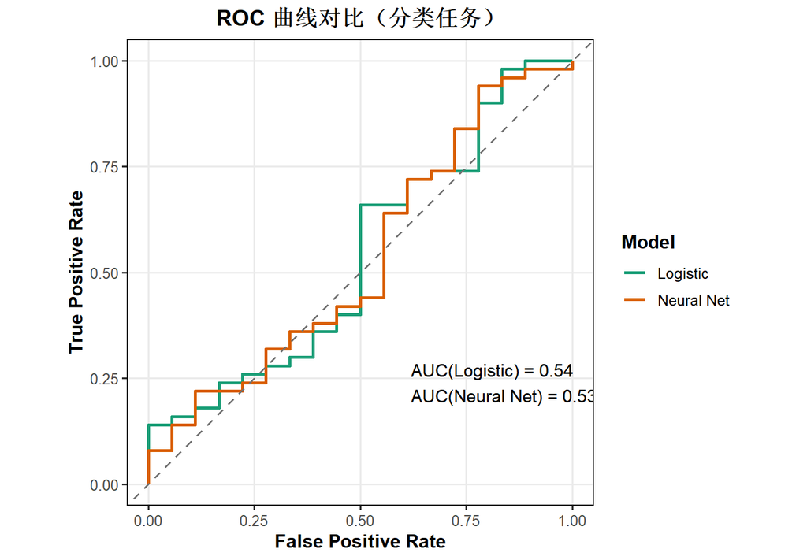

```r
roc_points <- function(y_true, y_prob) {
  ord <- order(y_prob, decreasing = TRUE)
  y_sorted <- y_true[ord]
  tp <- cumsum(y_sorted == 1)
  fp <- cumsum(y_sorted == 0)
  pos <- sum(y_true == 1)
  neg <- sum(y_true == 0)
  data.frame(
    FPR = c(0, fp / neg, 1),
    TPR = c(0, tp / pos, 1)
  )
}

roc_logit <- roc_points(test$dead, prob_logit)
roc_logit$model <- "Logistic"
roc_nn <- roc_points(test$dead, prob_nn)
roc_nn$model <- "Neural Net"
roc_df <- rbind(roc_logit, roc_nn)

ggplot(roc_df, aes(x = FPR, y = TPR, color = model)) +
  geom_line(linewidth = 1.05) +
  geom_abline(slope = 1, intercept = 0, linetype = "dashed", color = "gray45") +
  annotate("text", x = 0.62, y = 0.24, size = 4.0, hjust = 0,
           label = paste0(
             "AUC(Logistic) = ", round(cls_cmp["logistic", "AUC"], 3), "\n",
             "AUC(Neural Net) = ", round(cls_cmp["neural_net", "AUC"], 3)
           )) +
  scale_color_manual(values = c("Logistic" = "#1B9E77", "Neural Net" = "#D95F02")) +
  labs(
    title = "ROC 曲线对比（分类任务）",
    x = "False Positive Rate",
    y = "True Positive Rate",
    color = "Model"
  ) +
  coord_equal()
```

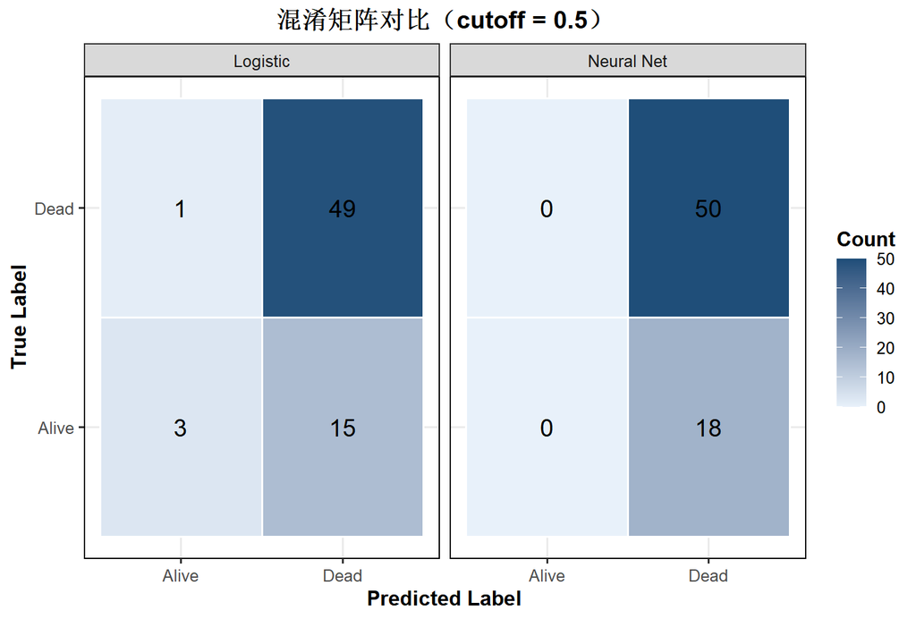

```r
make_conf_df <- function(y_true, y_prob, model_name, cutoff = 0.5) {
  y_pred <- ifelse(y_prob >= cutoff, 1, 0)
  tab <- table(
    Truth = factor(y_true, levels = c(0, 1), labels = c("Alive", "Dead")),
    Pred = factor(y_pred, levels = c(0, 1), labels = c("Alive", "Dead"))
  )
  out <- as.data.frame(tab)
  out$model <- model_name
  out
}

cm_df <- rbind(
  make_conf_df(test$dead, prob_logit, "Logistic"),
  make_conf_df(test$dead, prob_nn, "Neural Net")
)

ggplot(cm_df, aes(x = Pred, y = Truth, fill = Freq)) +
  geom_tile(color = "white", linewidth = 0.6) +
  geom_text(aes(label = Freq), size = 5.0) +
  scale_fill_gradient(low = "#E8F1FA", high = "#1F4E79") +
  facet_wrap(~ model) +
  labs(
    title = "混淆矩阵对比（cutoff = 0.5）",
    x = "Predicted Label",
    y = "True Label",
    fill = "Count"
  )
```

## 6.3 5.3 分类结果分析

- 逻辑回归可解释性强（系数可转化为 OR）；神经网络对复杂非线性关系更敏感。
- 本次实验中：
  - Logistic：Accuracy=0.765，AUC=0.54
  - Neural Net：Accuracy=0.735，AUC=0.533

在当前划分下，logistic 在 AUC 上更优。

# 7 6. 假设检验

问题描述：在模型比较之外，需要回答临床上常见的“组间差异是否显著”问题。本节以性别分组为例，分别检验生存时间均值差异与死亡率差异。

## 7.1 6.1 生存时间按性别分组比较（Welch t 检验）

检验问题：男性与女性生存时间均值是否存在差异？
$$H_0:\mu_{male}=\mu_{female},\quad H_1:\mu_{male}\neq\mu_{female}.$$

```r
t_sex <- t.test(time ~ sex, data = df, var.equal = FALSE)
t_sex
```

```
##
##  Welch Two Sample t-test
##
## data:  time by sex
## t = -1.9843, df = 196.51, p-value = 0.04861
## alternative hypothesis: true difference in means between group male and group female is not equal to 0
## 95 percent confidence interval:
##  -111.1266705   -0.3428947
## sample estimates:
##   mean in group male mean in group female
##             283.2319             338.9667
```

## 7.2 6.2 死亡率按性别比较（两比例检验）

$$H_0:p_{male}=p_{female},\quad H_1:p_{male}\neq p_{female}.$$

```r
male_dead <- sum(df$dead[df$sex == "male"])
female_dead <- sum(df$dead[df$sex == "female"])
male_n <- sum(df$sex == "male")
female_n <- sum(df$sex == "female")

prop_sex <- prop.test(x = c(male_dead, female_dead), n = c(male_n, female_n), correct = FALSE)
prop_sex
```

```
##
##  2-sample test for equality of proportions without continuity correction
##
## data:  c(male_dead, female_dead) out of c(male_n, female_n)
## X-squared = 13.511, df = 1, p-value = 0.0002371
## alternative hypothesis: two.sided
## 95 percent confidence interval:
##  0.1019165 0.3434942
## sample estimates:
##    prop 1    prop 2
## 0.8115942 0.5888889
```

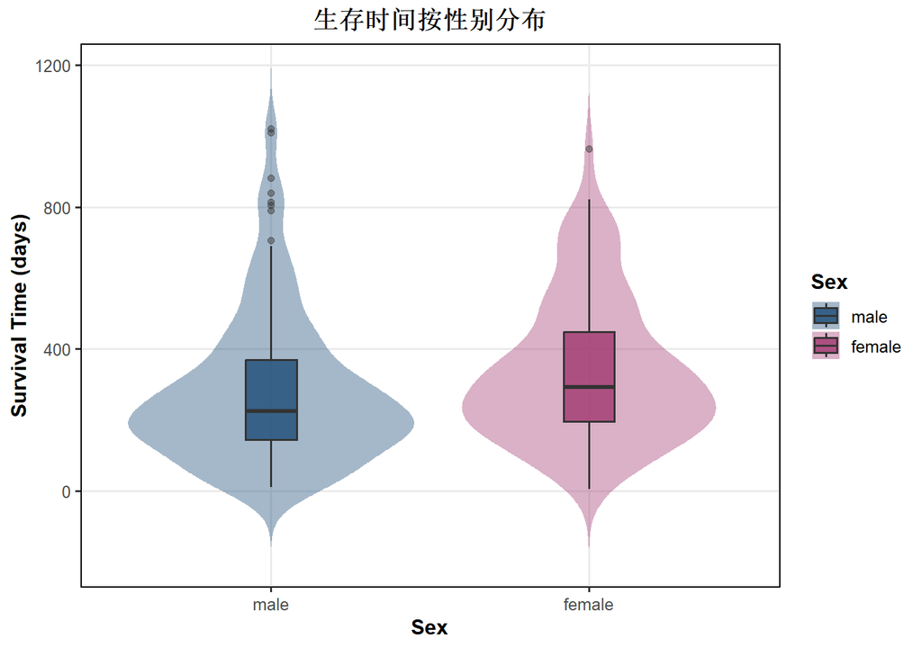

```r
mortality_by_sex <- do.call(
  rbind,
  lapply(levels(df$sex), function(s) {
    n <- sum(df$sex == s)
    k <- sum(df$dead[df$sex == s])
    ci <- binom.test(k, n)$conf.int
    data.frame(sex = s, rate = k / n, ci_low = ci[1], ci_high = ci[2], n = n)
  })
)

p_time <- ggplot(df, aes(x = sex, y = time, fill = sex)) +
  geom_violin(trim = FALSE, alpha = 0.4, color = NA) +
  geom_boxplot(width = 0.16, outlier.alpha = 0.45, alpha = 0.82) +
  scale_fill_manual(values = c(male = "#1F4E79", female = "#A23B72")) +
  labs(title = "生存时间按性别分布", x = "Sex", y = "Survival Time (days)", fill = "Sex")

p_rate <- ggplot(mortality_by_sex, aes(x = sex, y = rate, fill = sex)) +
  geom_col(width = 0.58, alpha = 0.85) +
  geom_errorbar(aes(ymin = ci_low, ymax = ci_high), width = 0.12, linewidth = 0.85) +
  scale_fill_manual(values = c(male = "#1F4E79", female = "#A23B72")) +
  labs(title = "死亡率按性别比较（含95%区间）", x = "Sex", y = "Death Rate") +
  coord_cartesian(ylim = c(0, 1))

p_time
```

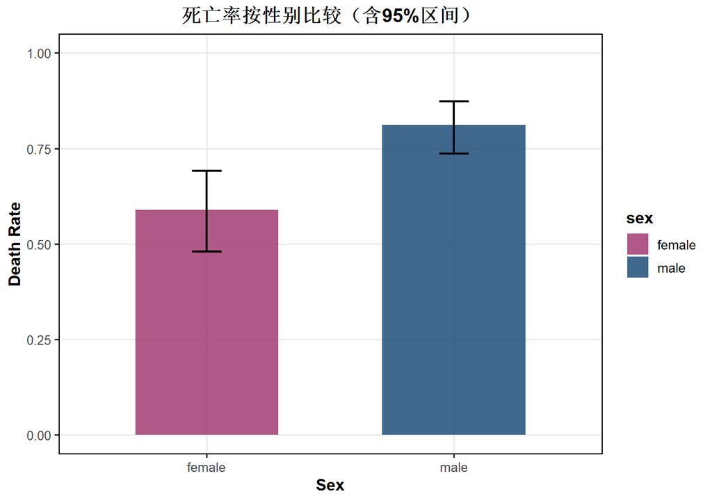

```r
p_rate
```

# 8 7. 区间估计

问题描述：除显著性检验外，还需报告参数估计的不确定性范围，以支持医学解释与决策沟通。

## 8.1 7.1 均值区间（t 区间）

对于总体均值 $\mu$，
$$\bar X \pm t_{1-\alpha/2,n-1}\frac{S}{\sqrt n}.$$

## 8.2 7.2 比例区间

大样本下比例 $p$ 可用近似区间
$$\hat p \pm z_{1-\alpha/2}\sqrt{\frac{\hat p(1-\hat p)}{n}}.$$

```r
mean_ci <- t.test(df$time)$conf.int
dead_ci <- binom.test(sum(df$dead), nrow(df))$conf.int

interval_summary <- data.frame(
  metric = c("mean_time", "dead_rate"),
  estimate = c(mean(df$time), mean(df$dead)),
  ci_low = c(mean_ci[1], dead_ci[1]),
  ci_high = c(mean_ci[2], dead_ci[2])
)
interval_summary$estimate <- round(interval_summary$estimate, 4)
interval_summary$ci_low <- round(interval_summary$ci_low, 4)
interval_summary$ci_high <- round(interval_summary$ci_high, 4)
interval_summary
```

```
##      metric estimate   ci_low  ci_high
## 1 mean_time 305.2325 277.7437 332.7212
## 2 dead_rate   0.7237   0.6608   0.7807
```

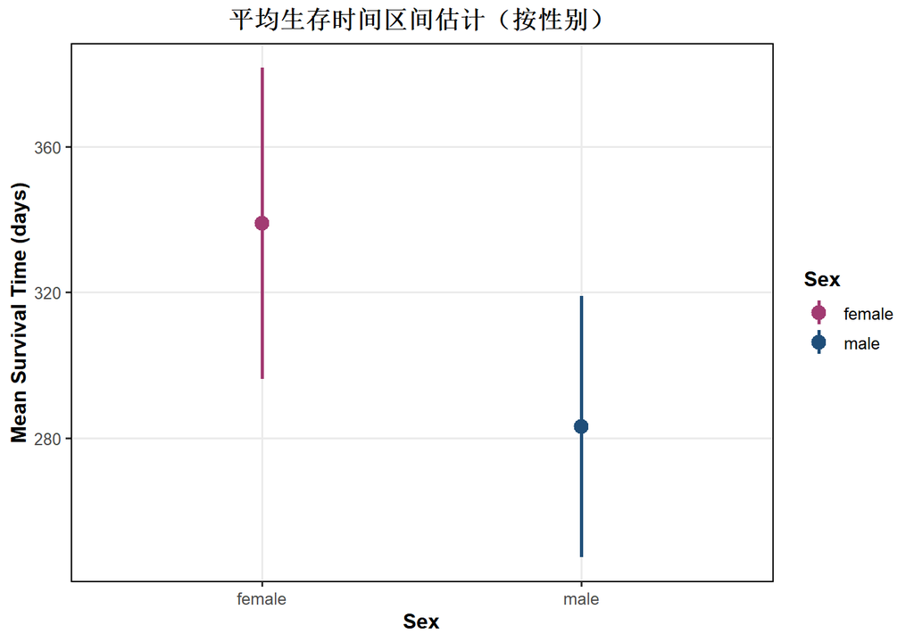

```r
mean_ci_by_sex <- do.call(
  rbind,
  lapply(levels(df$sex), function(s) {
    x <- df$time[df$sex == s]
    ci <- t.test(x)$conf.int
    data.frame(sex = s, estimate = mean(x), ci_low = ci[1], ci_high = ci[2])
  })
)

prop_ci_by_sex <- do.call(
  rbind,
  lapply(levels(df$sex), function(s) {
    n <- sum(df$sex == s)
    k <- sum(df$dead[df$sex == s])
    ci <- binom.test(k, n)$conf.int
    data.frame(sex = s, estimate = k / n, ci_low = ci[1], ci_high = ci[2])
  })
)

p_mean_ci <- ggplot(mean_ci_by_sex, aes(x = sex, y = estimate, color = sex)) +
  geom_pointrange(aes(ymin = ci_low, ymax = ci_high), linewidth = 0.9, size = 0.7) +
  scale_color_manual(values = c(male = "#1F4E79", female = "#A23B72")) +
  labs(title = "平均生存时间区间估计（按性别）", x = "Sex", y = "Mean Survival Time (days)", color = "Sex")

p_prop_ci <- ggplot(prop_ci_by_sex, aes(x = sex, y = estimate, color = sex)) +
  geom_pointrange(aes(ymin = ci_low, ymax = ci_high), linewidth = 0.9, size = 0.7) +
  scale_color_manual(values = c(male = "#1F4E79", female = "#A23B72")) +
  labs(title = "死亡率区间估计（按性别）", x = "Sex", y = "Death Rate") +
  coord_cartesian(ylim = c(0, 1))

p_mean_ci
```

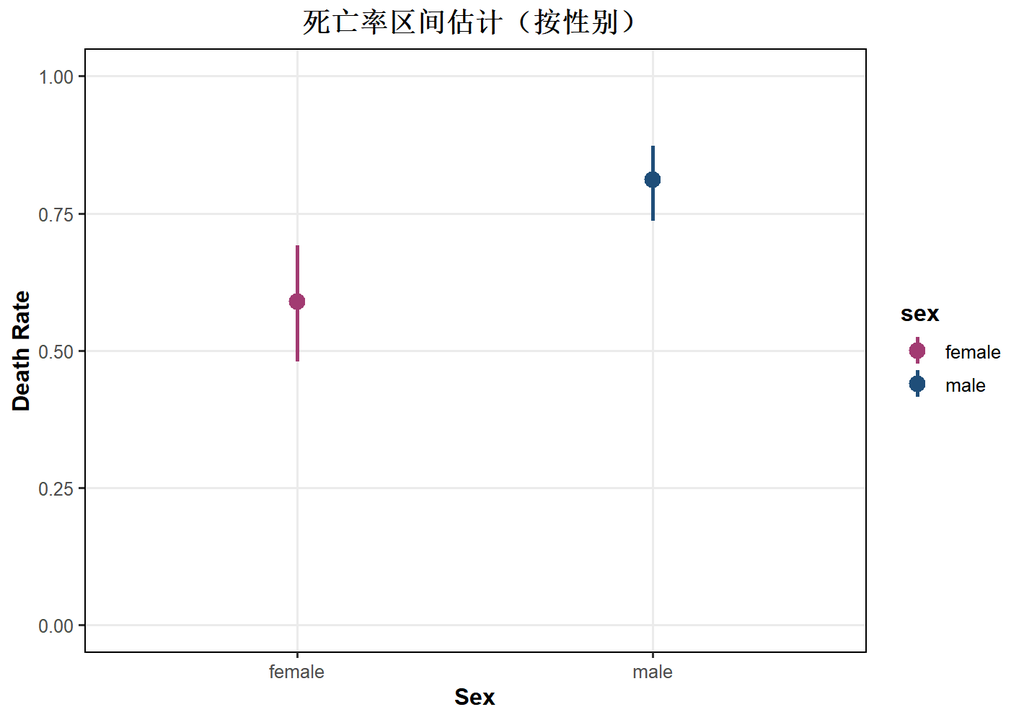

```r
p_prop_ci
```

区间估计解读：

- 生存时间均值点估计：305.23，95%CI=[277.74, 332.72]
- 死亡率点估计：0.724，95%CI=[0.661, 0.781]

# 9 8. 总结：三类回归 + 两类分类的优劣

## 9.1 8.1 回归模型比较（本实验）

1. 线性回归：解释性强、实现简单，对线性关系友好。
2. 多项式回归：在保持较好解释性的同时捕获部分非线性。
3. 全连接神经网络：表达能力强，但参数多、可解释性弱、对预处理敏感。

## 9.2 8.2 分类模型比较（本实验）

1. 逻辑回归：参数可解释（OR），适合临床结论表达。
2. 全连接神经网络：在复杂边界下可能表现更好，但不易解释。

## 9.3 8.3 方法选择建议

- 若目标是“解释机制”：优先线性/逻辑回归。
- 若目标是“预测精度”且样本量足够：可尝试神经网络并做验证。
- 在生物统计场景中，建议“可解释模型 + 高性能模型”并行报告。

# 10 9. 课后作业：撰写一篇小论文

作业任务：将本节实验整理为一篇完整小论文（建议 3000-5000 字），主题可定为“基于肺癌临床数据的回归与分类建模比较研究”。

## 10.1 9.1 建议论文结构（可直接套用）

1. 引言（Introduction）  
   说明研究背景、问题意义与本文研究目标：为什么要同时做回归（`time`）和分类（`dead`）任务。
2. 数据与方法（Materials and Methods）  
   写清数据来源、样本量、变量定义、缺失值处理、训练测试划分、标准化步骤，并给出核心模型公式（线性/多项式/三隐藏层神经网络、逻辑回归）。
3. 结果（Results）  
   按“数据概览 -> 相关性 -> 回归结果 -> 分类结果 -> 检验与区间估计”展开，图表为主、文字解释为辅。  
   要求明确报告 Train/Test 的关键指标（MSE、MAE、RMSE、R2、AUC 等）。
4. 讨论（Discussion）  
   解释模型差异的原因，讨论神经网络在本数据上优势不明显的可能机制，并分析研究限制（样本量、删失信息、超参数、单次划分等）。
5. 结论（Conclusion）  
   用 3-5 条结论回答研究问题，指出本实验在生物统计实践中的启发和后续改进方向。

## 10.2 9.2 提交要求

1. 提交文件  
   提交 1 个主文档：`mini_paper.pdf`（或 `mini_paper.docx`），以及 1 个复现实验脚本：`analysis.R`（或 `analysis.Rmd`）。
2. 图表规范  
   每张图必须有图题、坐标轴名称、图例与必要单位；正文中需引用图表并解释“它支持了什么结论”。
3. 结果报告规范  
   核心指标需同时给出训练集与测试集结果，并在文字中解释泛化表现，避免只报数值不解释。
4. 学术写作规范  
   采用学术语言，术语前后一致；方法、结果、讨论分段清楚；结论必须由结果支撑，不得主观下结论。
5. 可复现性  
   保证他人能按你提供的脚本复现主要结果；若有随机性，请固定随机种子并在文中注明。

## 10.3 9.3 新增要求：插图达到科研论文质量

1. 所有插图必须统一风格  
   包括统一字体、字号、配色、线宽、图例位置与边距，避免同一论文中图形风格混乱。
2. 所有插图必须信息完整  
   每图需包含图题、坐标轴名称、图例、单位（如适用），并保证缩放后文字仍清晰可读。
3. 所有插图必须满足投稿级导出质量  
   建议同时导出：
- 矢量图：`PDF/SVG`（优先用于线图、散点图、统计图）
- 位图：`TIFF/PNG`，分辨率建议 `>=300 dpi`（部分期刊建议 `600 dpi`）
4. 所有插图必须服务于结论  
   正文中每张图都要回答一个明确问题（例如“哪一个模型在测试集上误差更低”），禁止“只展示不解释”。
5. 在线教程（参考）  
   [ggpubr: ggplot2-Based Publication Ready Plots](https://rpkgs.datanovia.com/ggpubr/index.html)

## 10.4 9.4 论文级插图示例

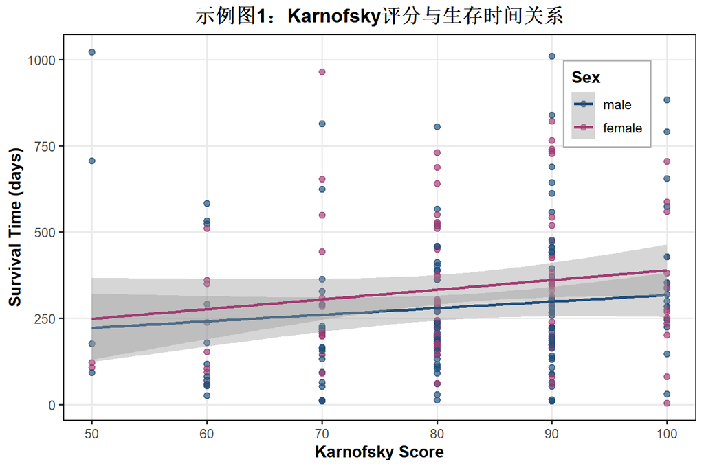

```r
ggplot(df, aes(x = ph.karno, y = time, color = sex)) +
  geom_point(alpha = 0.65, size = 2.0) +
  geom_smooth(method = "lm", se = TRUE, linewidth = 0.9) +
  scale_color_manual(values = c(male = "#1F4E79", female = "#A23B72")) +
  labs(
    title = "示例图1：Karnofsky评分与生存时间关系",
    x = "Karnofsky Score",
    y = "Survival Time (days)",
    color = "Sex"
  ) +
  theme(
    legend.position = c(0.86, 0.82),
    legend.background = element_rect(fill = "white", color = "grey70")
  )
```

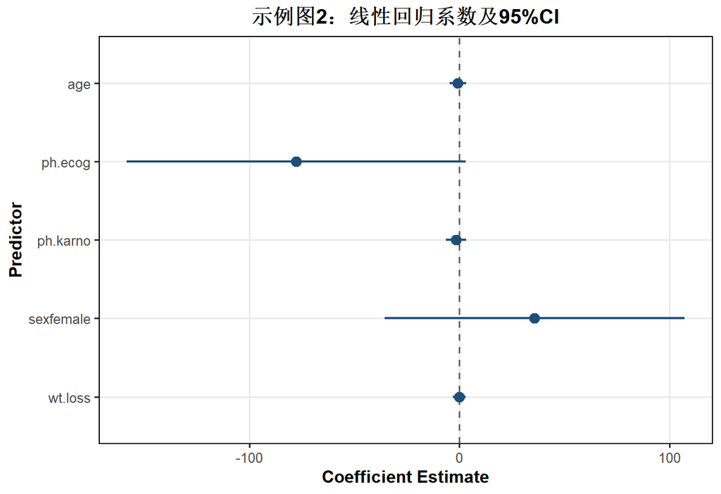

```r
coef_tbl <- data.frame(
  term = rownames(summary(lm_fit)$coefficients),
  estimate = summary(lm_fit)$coefficients[, "Estimate"],
  stringsAsFactors = FALSE
)
ci_tbl <- as.data.frame(confint(lm_fit))
ci_tbl$term <- rownames(ci_tbl)
colnames(ci_tbl)[1:2] <- c("ci_low", "ci_high")
coef_tbl <- merge(coef_tbl, ci_tbl, by = "term")
coef_tbl <- subset(coef_tbl, term != "(Intercept)")
coef_tbl$term <- factor(coef_tbl$term, levels = rev(coef_tbl$term))

ggplot(coef_tbl, aes(x = term, y = estimate)) +
  geom_hline(yintercept = 0, linetype = "dashed", color = "gray40") +
  geom_pointrange(aes(ymin = ci_low, ymax = ci_high), color = "#1F4E79", linewidth = 0.8) +
  coord_flip() +
  labs(
    title = "示例图2：线性回归系数及95%CI",
    x = "Predictor",
    y = "Coefficient Estimate"
  )
```

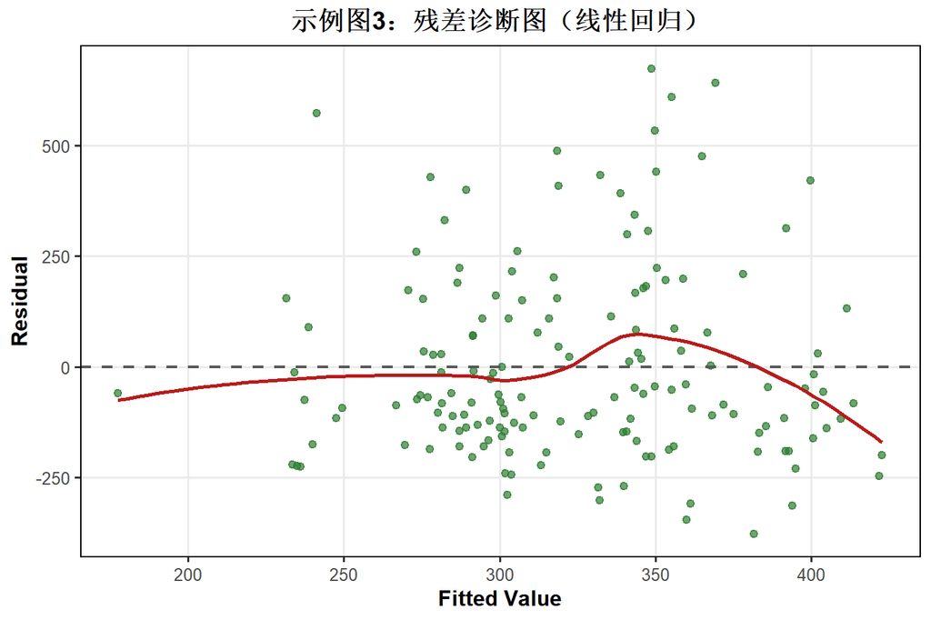

```r
resid_df <- data.frame(
  fitted = fitted(lm_fit),
  resid = residuals(lm_fit)
)

ggplot(resid_df, aes(x = fitted, y = resid)) +
  geom_point(color = "#2E7D32", alpha = 0.7, size = 1.8) +
  geom_hline(yintercept = 0, linetype = "dashed", color = "gray35", linewidth = 0.8) +
  geom_smooth(method = "loess", se = FALSE, color = "#B71C1C", linewidth = 0.9) +
  labs(
    title = "示例图3：残差诊断图（线性回归）",
    x = "Fitted Value",
    y = "Residual"
  )
```

# 11 章末检查

- 我能从同一数据集中同时构建回归与分类任务
- 我能写出线性、多项式、神经网络、逻辑回归的核心公式
- 我能完成检验、区间估计并给出结果解释
- 我能比较模型优劣并说明选择依据